# Time-Series Movie Dataset Analysis

**Thesis Statement**: Men direct films across all genres and times at proportionally higher rates than women while female directors are concentrated in genres associated with lower gross earnings, with overall gross earnings gap increasing between female and male-directed films over time.

In order to provide evidence for the thesis statement we first join the genre and people data with the movies data set and create a new decade variable to be used in our analysis.

```r
movies_people <- movies %>%
  left_join(m_genre, by = c("year", "title"))

movies_pg <- movies_people %>%
  left_join(m_people, by = c("title", "year"))

movies_pg <- movies_pg %>%
  mutate(decade = floor(year / 10)*10)
```

Now we visualize the data to support our thesis.

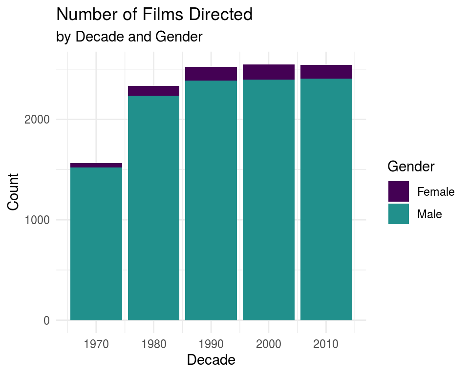

```r
movies_pg %>%
  filter(role == 'director', gender_conf >= 0.95) %>%
  group_by(gender, decade) %>%
  summarize(sm_count()) %>%
  ggplot() +
    geom_col(aes(decade, count, fill = gender)) +
    labs(
      title = 'Number of Films Directed',
      subtitle = 'by Decade and Gender',
      x = "Decade",
      y = "Count") +
    scale_fill_manual(name = "Gender", labels = c("Female", "Male"),
                      values = viridis::viridis(3))
```

We visualize the breakdown between female and male directors for each decade to see that while the total number of directors increases until the 2000s and decreases slightly in 2010s, the number of female directors is generally very small, compared to that of the males. We can infer that there should be some relationship between the number of films directed by females over time. However, the number of female directors is very small across all decades compared to that of males.

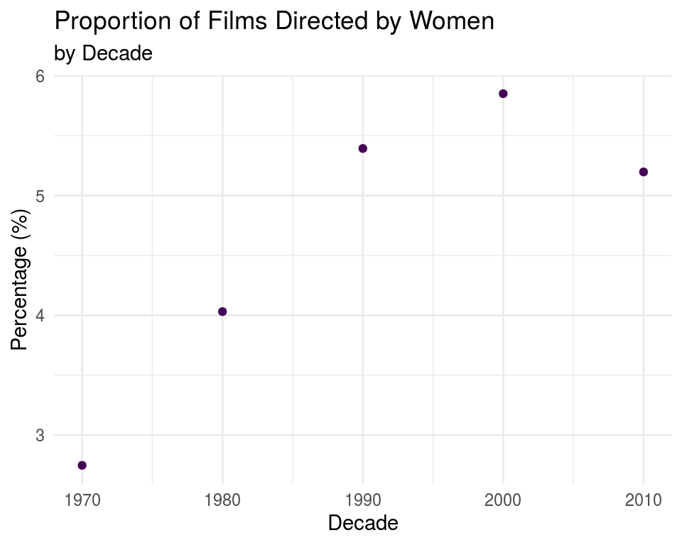

```r
movies_pg %>%
  filter(role == 'director', gender_conf >= 0.95, gender !='.') %>%
  group_by(decade) %>%
  mutate(is_female = as.numeric(gender == "female")) %>%
  summarize(gender_perc = mean(is_female*100)) %>%
  ggplot() +
    geom_point(aes(decade, gender_perc), color = viridis::viridis(1)) +
    labs(
      title = 'Proportion of Films Directed by Women',
      subtitle = 'by Decade',
      x = "Decade",
      y = "Percentage (%)")
```

We now show the proportion of female directors for each decade and see an increase from the 1970s through the 2000s, with a decrease of about half a percentage point from the highest percentage value in the 2010s. It has to be emphasized that even though there has been some increase in the proportion of female directors, the highest percentage it has achieved is just under 6% for all movies and genres.

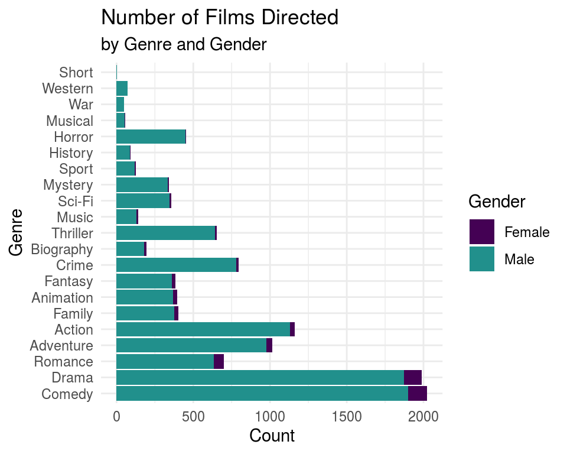

```r
movies_pg %>%
  filter(role == 'director', gender_conf > 0.95, genre != ".") %>%
  group_by(gender, genre) %>%
  summarize(sm_count()) %>%
  arrange(desc(count)) %>%
  mutate(m_genre = fct_inorder(genre)) %>%
  ggplot() +
    geom_col(aes(m_genre, count, fill = gender)) +
    coord_flip() +
    labs(
      title = 'Number of Films Directed',
      subtitle = 'by Genre and Gender',
      color = 'Gender',
      y = "Count",
      x = "Genre"
      ) +
    scale_fill_manual(name = "Gender", labels = c("Female", "Male"),
                      values = viridis::viridis(3))
```

We can also visualize the number of films directed by genre and gender, arranged by the increasing presence of female directors to see that the number of female directors varies by genre. Even if most films are directed by males, comedy and drama are the genres with the highest number of female directors.

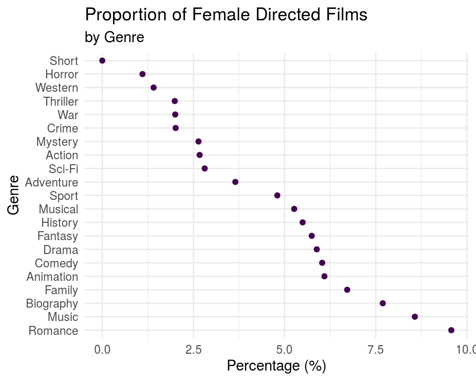

```r
movies_pg %>%
  filter(role == "director", gender_conf >= 0.95, genre != ".") %>%
  group_by(genre) %>%
  mutate(is_female = as.numeric(gender == "female")) %>%
  summarize(gender_perc = mean(is_female*100)) %>%
  arrange(desc(gender_perc)) %>%
  mutate(m_genre = fct_inorder(genre)) %>%
  ggplot() +
    geom_point(aes(m_genre, gender_perc), color = viridis::viridis(1)) +
    coord_flip() +
    labs(
      title = 'Proportion of Female Directed Films',
      subtitle = 'by Genre',
      y = "Percentage (%)",
      x = "Genre"
      )
```

In order to see the breakdown of directors by gender more clearly, we calculate the percentage of female directors for each genre. Now we can see that the highest proportion of females direct films in music and romance genres. However, the highest percentage of female directors is still only under 10%. This is a very low number.

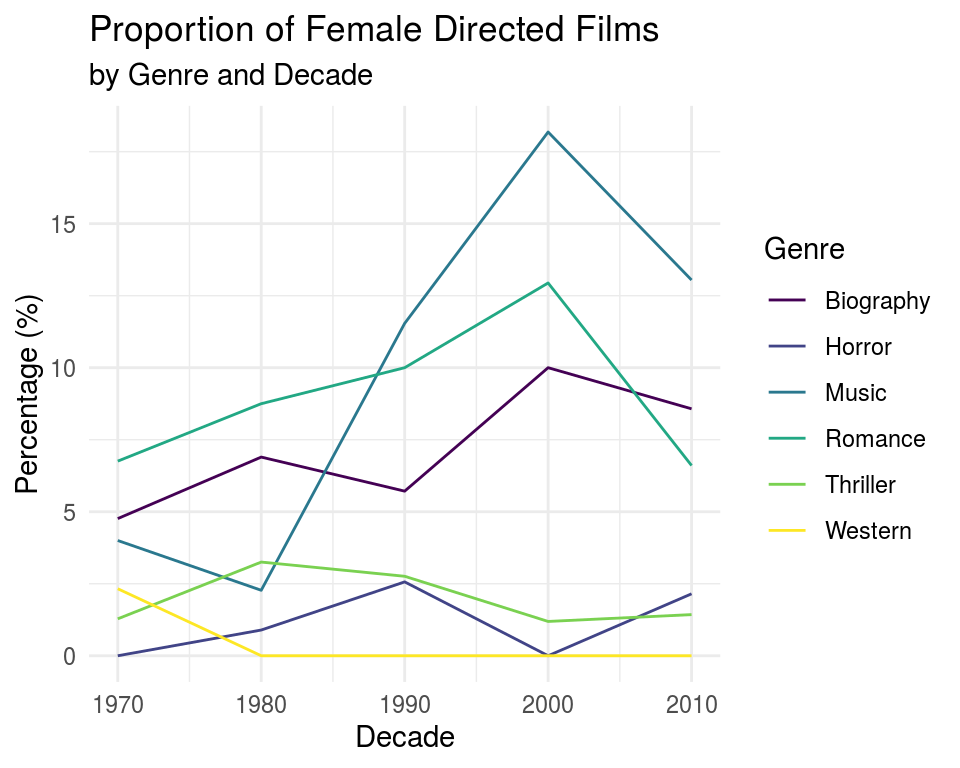

```r
movies_pg %>%
  filter(role == "director", gender_conf >= 0.95, genre != ".") %>%
  group_by(decade, genre) %>%
  filter(genre == "Romance" | genre == "Music" | genre == "Biography" |
           genre == "Thriller" | genre == "Horror" | genre == "Western") %>%
  mutate(is_female = as.numeric(gender=="female")) %>%
  summarize(gender_perc = mean(is_female*100)) %>%
  ggplot() +
    geom_line(aes(decade, gender_perc, color = genre)) +
    labs(
      title = 'Proportion of Female Directed Films',
      subtitle = 'by Genre and Decade',
      color = 'Genre',
      y = "Percentage (%)",
      x = "Decade"
      ) +
  scale_color_viridis_d()
```

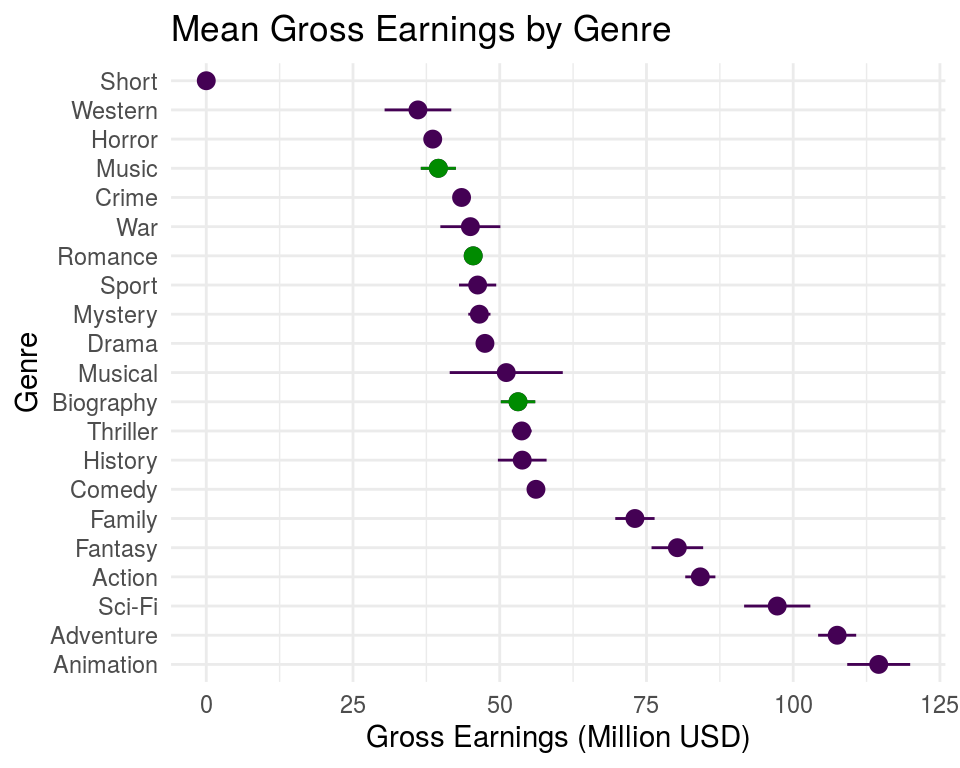

```r
sel_m_genres <- movies_pg %>%
                filter(genre != ".", genre == "Romance" | genre == "Music" |
                       genre == "Biography") %>%
                group_by(genre) %>%
                summarize(sm_mean_cl_normal(gross))

movies_pg %>%
  filter(genre != ".") %>%
  group_by(genre) %>%
  summarize(sm_mean_cl_normal(gross)) %>%
  arrange(desc(gross_mean)) %>%
  mutate(m_genre = fct_inorder(genre)) %>%
  ggplot() +
    geom_pointrange(aes(m_genre, gross_mean, ymin = gross_ci_min,
                        ymax = gross_ci_max), color = viridis::viridis(1)) +
    geom_pointrange(aes(genre, gross_mean, ymin = gross_ci_min,
                        ymax = gross_ci_max), color = 'green4',
                        data = sel_m_genres) +
    coord_flip() +
    labs(
      title = 'Mean Gross Earnings by Genre',
      y = "Gross Earnings (Million USD)",
      x = "Genre"
      )
```

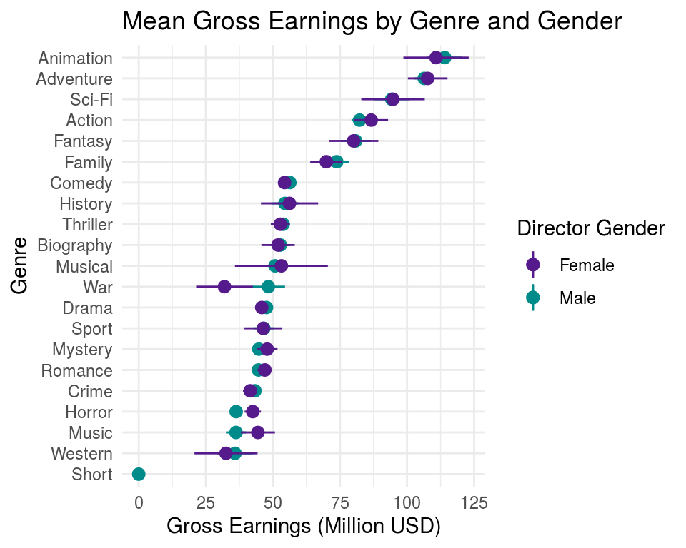

```r
femaledir <- movies_pg %>%
        filter(genre != ".", gender_conf >= 0.95, gender == 'female') %>%
        group_by(genre) %>%
        summarize(sm_mean_cl_normal(gross))

colors <- c("Female" = "purple4", "Male" = "cyan4")

movies_pg %>%
  filter(genre != ".", gender_conf >= 0.95, gender == 'male') %>%
  group_by(genre) %>%
  summarize(sm_mean_cl_normal(gross)) %>%
  arrange(gross_mean) %>%
  mutate(m_genre = fct_inorder(genre)) %>%
  ggplot() +
    geom_pointrange(aes(m_genre, gross_mean, ymin = gross_ci_min,
                        ymax = gross_ci_max, color = "Male")) +
    geom_pointrange(aes(genre, gross_mean, ymin = gross_ci_min,
                        ymax = gross_ci_max, color = "Female"),
                        data = femaledir) +
    coord_flip() +
    labs(
      title = 'Mean Gross Earnings by Genre and Gender',
      y = "Gross Earnings (Million USD)",
      x = "Genre",
      color = "Director Gender"
      ) +
    scale_color_manual(values = colors)
```

We also compare mean gross earnings for each genre when directed by men versus women. We find the means for female and male directed films to be generally quite close in this case.

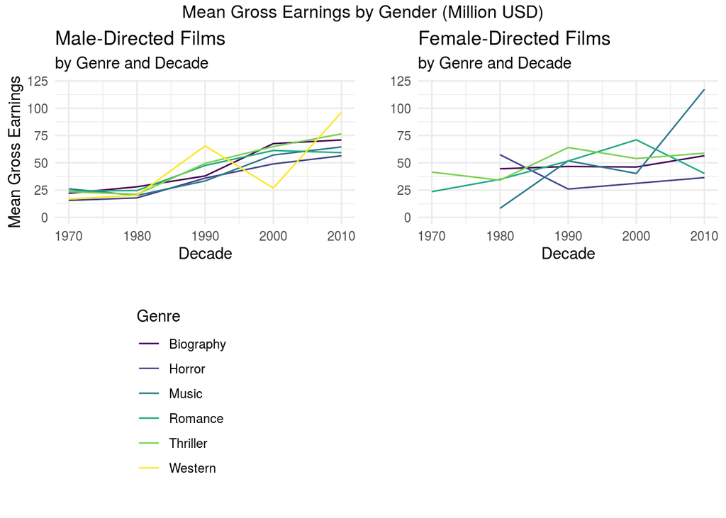

```r
m <- movies_pg %>%
  filter(role == "director", gender == "male", gender_conf >= 0.95, genre != ".") %>%
  group_by(decade, genre) %>%
  filter(genre == "Romance" | genre == "Music" | genre == "Biography" |
           genre == "Thriller" | genre == "Horror" | genre == "Western") %>%
  summarize(sm_mean(gross)) %>%
  ggplot() +
    geom_line(aes(decade, gross_mean, color = genre)) +
    labs(
      title = 'Male-Directed Films',
      subtitle = 'by Genre and Decade',
      color = 'Genre',
      y = "Mean Gross Earnings",
      x = "Decade"
      ) +
    ylim(0, 120) +
    theme(legend.position = "none") +
    scale_color_viridis_d()

f <- movies_pg %>%
  filter(role == "director", gender == "female", gender_conf >= 0.95,
         genre != ".") %>%
  group_by(decade, genre) %>%
  filter(genre == "Romance" | genre == "Music" | genre == "Biography" |
           genre == "Thriller" | genre == "Horror" | genre == "Western") %>%
  summarize(sm_mean(gross)) %>%
  ggplot() +
    geom_line(aes(decade, gross_mean, color = genre)) +
    labs(
      title = 'Female-Directed Films',
      subtitle = 'by Genre and Decade',
      color = 'Genre',
      y = "",
      x = "Decade"
      ) +
    ylim(0, 120) +
    scale_color_viridis_d()

get_legend<-function(myggplot){
  tmp <- ggplot_gtable(ggplot_build(myggplot))
  leg <- which(sapply(tmp$grobs, function(x) x$name) == "guide-box")
  legend <- tmp$grobs[[leg]]
  return(legend)
}

legend <- get_legend(f)

f <- f + theme(legend.position = "none")

grid.arrange(m, f, nrow=2, top = "Mean Gross Earnings by Gender (Million USD)", legend)
```

If we plot mean gross earnings by decade and genre we see that male-directed films have generally been doing better in terms of earnings in the 2000s and the 2010s with the exception of music in the 2010s and romance in the 2000s. The data before the 2000s is unreliable for comparison as it contains very few or no observations for female-directed films.

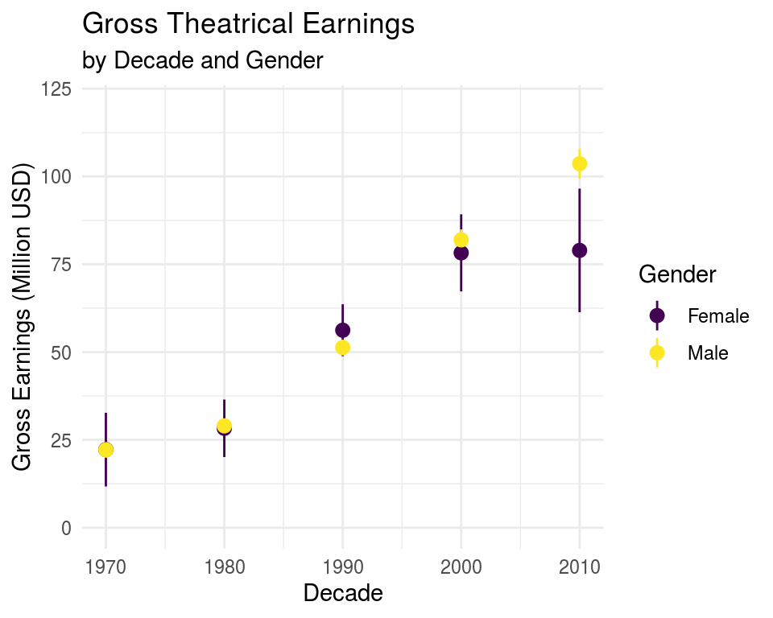

```r
movies_pg %>%
  filter(role == 'director') %>%
  filter(gender_conf > 0.95) %>%
  group_by(gender, decade) %>%
  summarize(sm_mean_cl_normal(gross)) %>%
  ggplot() +
    geom_pointrange(aes(x = decade, y = gross_mean, ymin = gross_ci_min,
                        ymax = gross_ci_max, color = gender)) +
    labs(
      title = 'Gross Theatrical Earnings',
      subtitle = 'by Decade and Gender',
      color = 'Gender',
      x = "Decade",
      y = "Gross Earnings (Million USD)"
      ) +
    ylim(0, 120) +
    scale_color_manual(name = "Gender", labels = c("Female", "Male"),
                       values = viridis::viridis(2))
```

Finally, we visualize the mean gross theatrical earnings with confidence intervals for male and female directed movies by decade. From the plot above we see that if in the 70s and 80s the mean gross theatrical earnings were close for female and male directed movies, we start to see a gap appearing in the 2000s and, even more significantly, in the 2010s. It has to be noted that in the 1990s female-directed film earnings, on average, slightly exceeded male-directed film earnings. This, however, is likely to be an exception to the rule. It is also worth noting that female-directed film earnings seem to vary more, compared to male-directed films.